# Story Time

Timothy Oliver

2023-11-07

```r
pop_githubs <- read.csv("../../MUSA_6951_Assignment3-TO/HW3_theme_and_graphs/data/repositories.csv")
pop_githubs$Language[pop_githubs$Language==""]<-"No Language"
# table(pop_githubs$Language)

sort(table(pop_githubs$Language))
top_10_lang<-c("Python","JavaScript","No Language","Java","TypeScript","C++","Go","C","C#","PHP")
repos_in10Lang<-pop_githubs[pop_githubs$Language %in% top_10_lang,]
```

# Audience/Message Planning

- What is the company I am working/proposing for?
  - Who within it am I writing to?
    - CEO
    - head of hiring
    - head of communications
  - Why do they want new visualizations?
    - new company
      - new primary stockholder/leadership, etc.
    - simple fancy of leadership
    - expressed need for specific project(s)
  - How long do we expect the recommendation to take?
    - length of training… 6-12 months for confident/seamless integration
    - hiring… 2-3 hiring cycles (say every 3 months so 6-9 months)

# The Story

As our company moves to a focus on creating project dashboards and visualizations for team and stockholder meetings, there has been difficulty in assessing the abilities of new potential hires. I propose increasing the company’s awareness of Github in two sections…

1. Requiring Human Resources to…
   - verify applicants’ related Github projects
   - encourage applicable departments to review work and reproducibility
2. Encouraging various departments to use Github (or relevant source control) to create and distribute visualization templates across the company.

Improved use of source control in the company’s hiring and work practices will solve current and future visualization challenges.

## What should we look for?

- Hiring
  - consider importance of python and javascript
    - python for data manipulation and exploration
    - python support via libraries
    - javascript for frontend visualizations and final products
  - Github popularity of python and javascript
    - shows general user support for these languages outweighs others
    - would not severely diminish pool of potential workers
    - new hires likely to be proficient or exposed to these languages

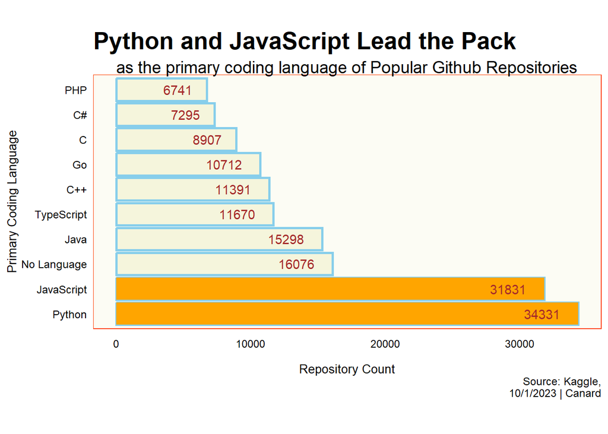

```r
# x_tick_labs<- names(table(repos_in10Lang$Language))
# reorder(x_tick_labs,x_tick_labs,function(x)-length(x))
x_tick_labs<-c("Python","JS","No Language","Java","TypeScript","C++","Go","C","C","PHP")

# plot of most common by language and count
p <- ggplot(data = repos_in10Lang,
            mapping = aes(x=reorder(Language,Language,function(x)-length(x))))+
  geom_bar(fill="beige",color="skyblue",linewidth=1)+
  geom_bar(data=repos_in10Lang[(repos_in10Lang$Language=="Python")|(repos_in10Lang$Language=="JavaScript"),],fill="orange")+
  geom_text(aes(label=..count..),stat="count",color="brown",hjust=1.5)+
  labs(x="Primary Coding Language",
       y= "Repository Count",
       title = "Python and JavaScript Lead the Pack",
       subtitle = "as the primary coding language of Popular Github Repositories",
       caption = "Source: Kaggle,\n10/1/2023 | Canard")+theme_test()+coord_flip()# adding +scale_x_discrete(x_tick_labs) did

# display plot
p
```

```r
## Get the state names and place results of the following in a dataframe for reference
### divide total count by population and make grad-symbol map or similar plot/map

state <- tolower("Pennsylvania")
stateUser <- fromJSON(rawToChar((GET(paste("https://api.github.com/search/users?q=location:",state,sep=""))$content)))$total_count
```

# Recommendation